# TREE:D

Lin Zhang

11/13/2020

```r
library(ISLR)
library(tree)
attach(Carseats)
library(dplyr)
```

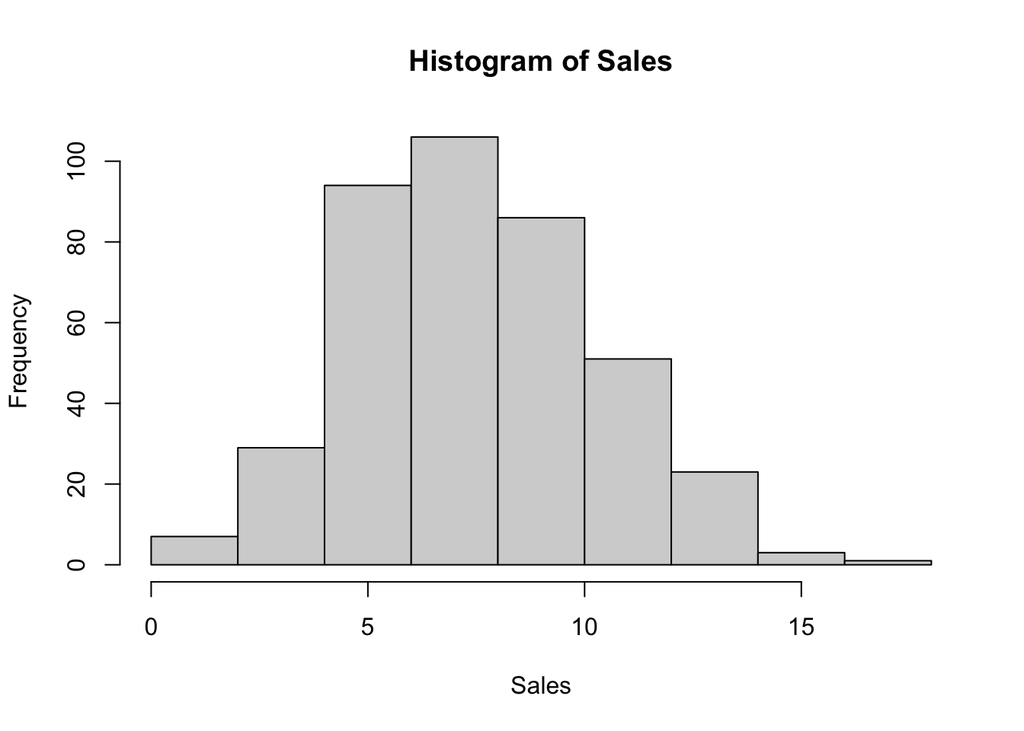

```r
hist(Sales)
```

```r
Carseats$High <- as.factor(ifelse(Sales<=8,"No","Yes"))
```

```r
tree.carseats=tree(High~.-Sales,data = Carseats) # High derived by Sales
summary(tree.carseats)
```

```
##
## Classification tree:
## tree(formula = High ~ . - Sales, data = Carseats)
## Variables actually used in tree construction:
## [1] "ShelveLoc"   "Price"       "Income"      "CompPrice"   "Population"
## [6] "Advertising" "Age"         "US"
## Number of terminal nodes:  27
## Residual mean deviance:  0.4575 = 170.7 / 373
## Misclassification error rate: 0.09 = 36 / 400
```

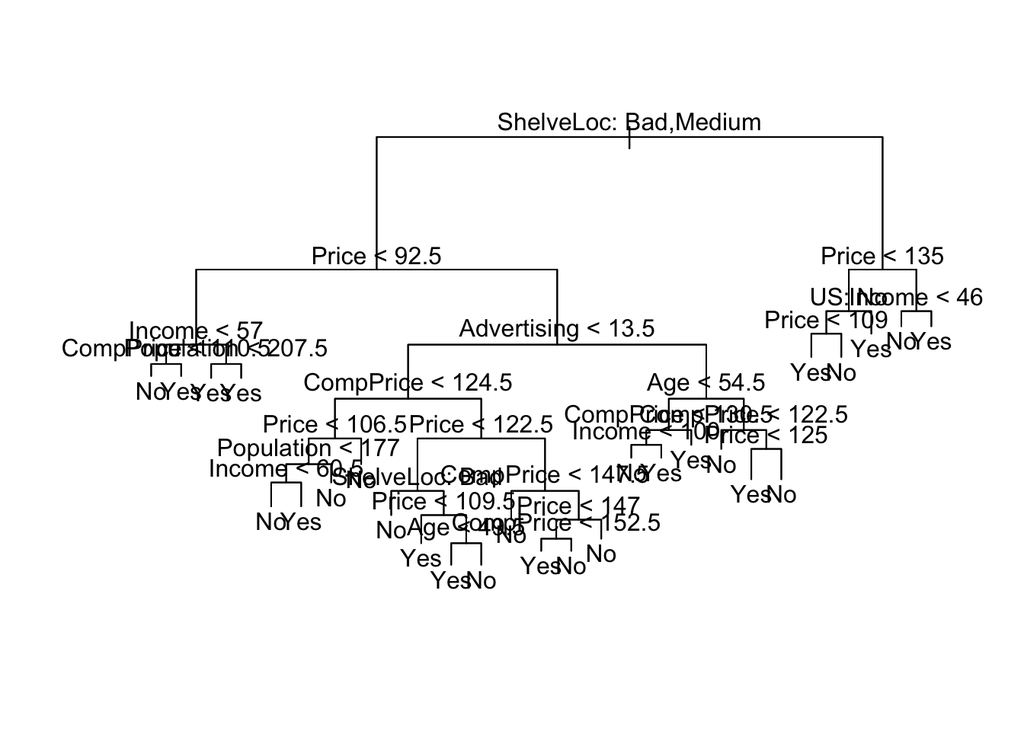

```r
plot(tree.carseats)
text(tree.carseats,pretty = 0)
```

# Problem 8. predict Sales response as a quantitative variable

## 8a

```r
# split train vs test
set.seed(2)
seat_idx = sample(1:nrow(Carseats),200)
seat_trn = Carseats[seat_idx,]
seat_tst = Carseats[-seat_idx,]
```

## 8b

```r
seat_tree_quan = tree(Sales ~.,data = seat_trn)
```

```r
summary(seat_tree_quan)
```

```
##
## Regression tree:
## tree(formula = Sales ~ ., data = seat_trn)
## Variables actually used in tree construction:
## [1] "High"        "Price"       "CompPrice"   "ShelveLoc"   "Age"
## [6] "Population"  "Advertising"
## Number of terminal nodes:  13
## Residual mean deviance:  1.365 = 255.3 / 187
## Distribution of residuals:
##     Min.  1st Qu.   Median     Mean  3rd Qu.     Max.
## -4.17000 -0.74210 -0.01017  0.00000  0.71470  3.56700
```

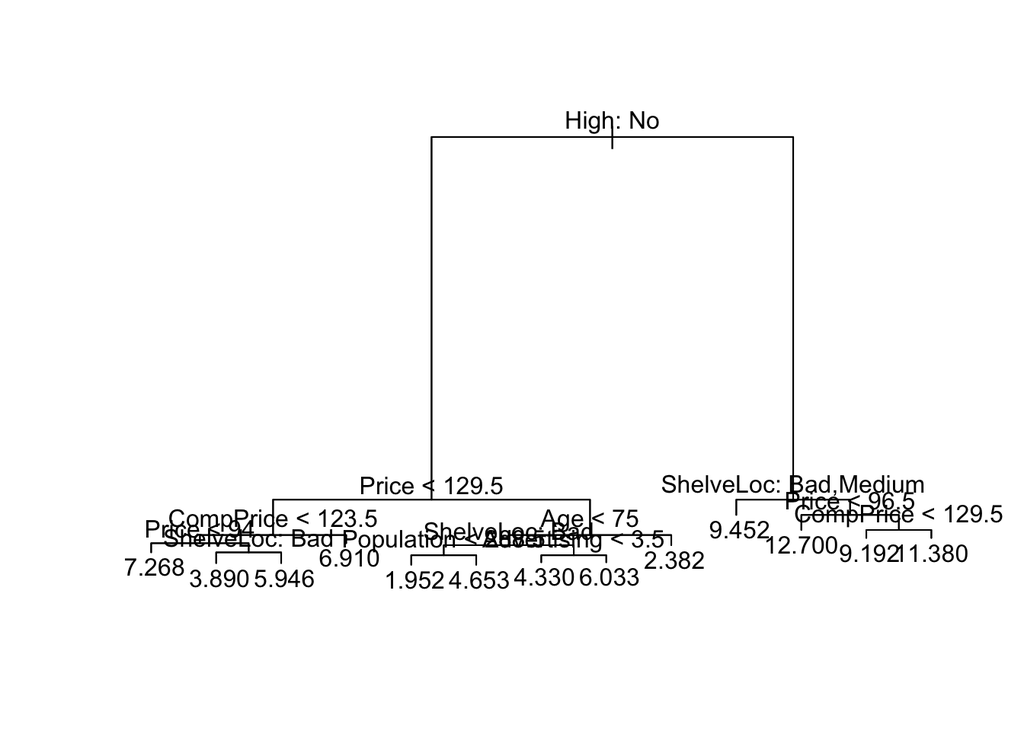

```r
plot(seat_tree_quan)
text(seat_tree_quan,pretty=0)
```

test MSE

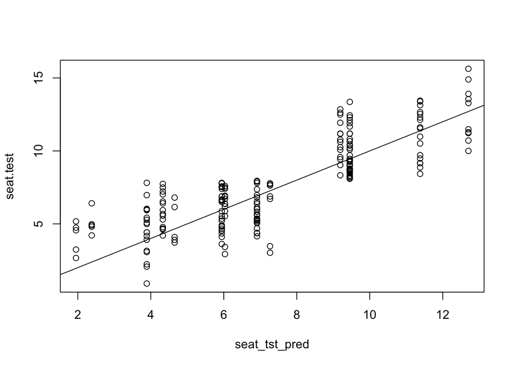

```r
seat_tst_pred = predict(seat_tree_quan,seat_tst)
seat.test = Carseats[-seat_idx,"Sales"]
plot(seat_tst_pred,seat.test)
abline(0,1)
```

```r
mean((seat_tst_pred- seat.test)^2)
```

```
## [1] 2.838771
```

## 8c

use CV to select a good tree complexity

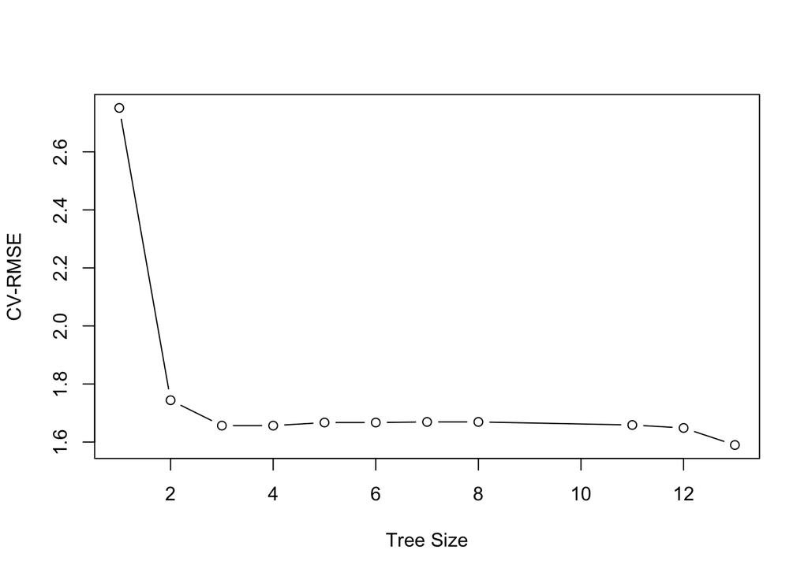

```r
set.seed(18)
seat_tree_quan_cv = cv.tree(seat_tree_quan)
plot(seat_tree_quan_cv$size, sqrt(seat_tree_quan_cv$dev/nrow(seat_trn)),type = "b",xlab = "Tree Size",ylab = "CV-RMSE") #?
```

```r
seat_tree_prune = prune.tree(seat_tree_quan,best = 10)
summary(seat_tree_prune)
```

```
##
## Regression tree:
## snip.tree(tree = seat_tree_quan, nodes = c(21L, 15L))
## Variables actually used in tree construction:
## [1] "High"       "Price"      "CompPrice"  "ShelveLoc"  "Age"
## [6] "Population"
## Number of terminal nodes:  11
## Residual mean deviance:  1.547 = 292.4 / 189
## Distribution of residuals:
##     Min.  1st Qu.   Median     Mean  3rd Qu.     Max.
## -5.19200 -0.78700  0.04304  0.00000  0.77930  3.56700
```

test MSE

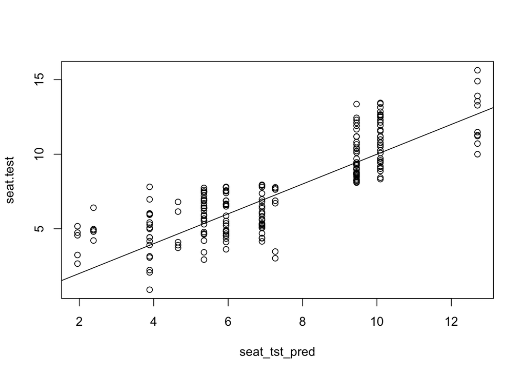

```r
seat_tst_pred = predict(seat_tree_prune,seat_tst)
seat.test = Carseats[-seat_idx,"Sales"]
plot(seat_tst_pred,seat.test)
abline(0,1)
```

```r
mean((seat_tst_pred- seat.test)^2)
```

```
## [1] 2.666092
```

## 8d bagging

```r
(bag.seat = randomForest::randomForest(Sales ~.,data = seat_trn,mtry=10,importance=TRUE))
```

```
##
## Call:
##  randomForest(formula = Sales ~ ., data = seat_trn, mtry = 10,      importance = TRUE)
##                Type of random forest: regression
##                      Number of trees: 500
## No. of variables tried at each split: 10
##
##           Mean of squared residuals: 2.151157
##                     % Var explained: 71.12
```

```r
bag.seat$mse[500]
```

```
## [1] 2.151157
```

test MSE # do we still need MSE here?

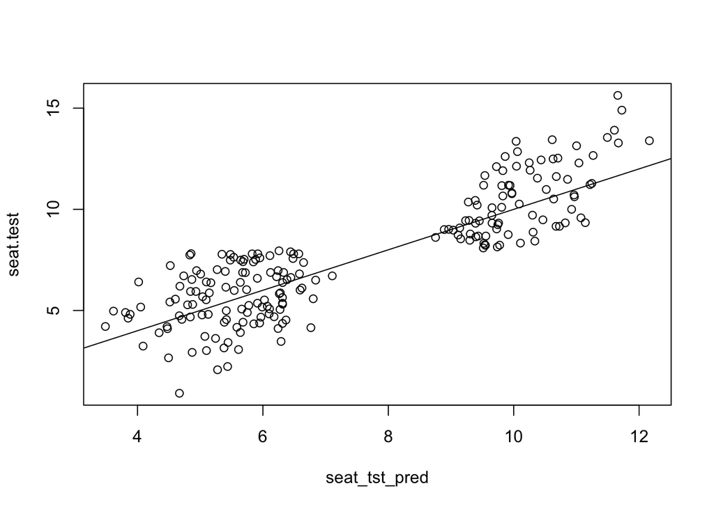

```r
seat_tst_pred = predict(bag.seat,seat_tst)
seat.test = Carseats[-seat_idx,"Sales"]
plot(seat_tst_pred,seat.test)
abline(0,1)
```

```r
mean((seat_tst_pred- seat.test)^2)
```

```
## [1] 2.149098
```

much lower!

```r
randomForest::importance(bag.seat)
```

```
##                %IncMSE IncNodePurity
## CompPrice   15.5046345     85.270293
## Income      -3.6896945     38.581346
## Advertising  0.6553305     42.296851
## Population   0.6459330     49.830676
## Price       32.0845358    199.889574
## ShelveLoc   19.8443306     73.125044
## Age          1.1054090     56.084356
## Education   -0.1513745     25.152150
## Urban        2.0030914      7.675247
## US           4.8986152      6.202227
## High        81.3674490    870.455696
```

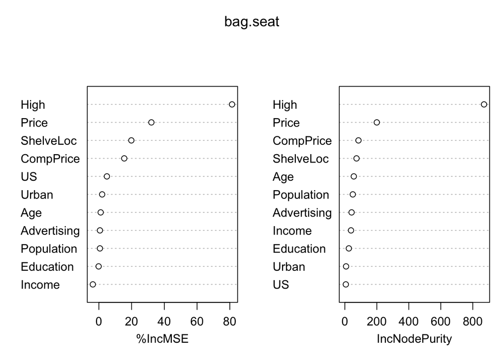

```r
randomForest::varImpPlot(bag.seat)
```

Price is more important

## 8e RF

```r
(RF.seat = randomForest::randomForest(Sales ~.,data = seat_trn,mtry=4,importance=TRUE))
```

```
##
## Call:
##  randomForest(formula = Sales ~ ., data = seat_trn, mtry = 4,      importance = TRUE)
##                Type of random forest: regression
##                      Number of trees: 500
## No. of variables tried at each split: 4
##
##           Mean of squared residuals: 2.047614
##                     % Var explained: 72.51
```

```r
RF.seat$mse[500]
```

```
## [1] 2.047614
```

test MSE

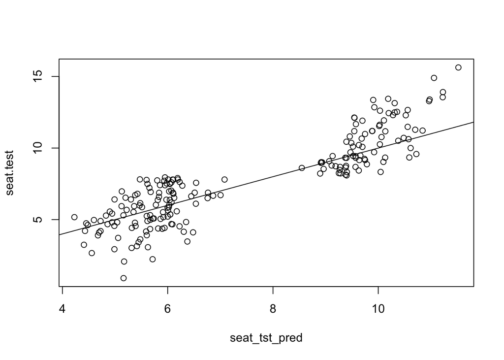

```r
seat_tst_pred = predict(RF.seat,seat_tst)
seat.test = Carseats[-seat_idx,"Sales"]
plot(seat_tst_pred,seat.test)
abline(0,1)
```

```r
mean((seat_tst_pred- seat.test)^2)
```

```
## [1] 2.022652
```

not too bad

```r
randomForest::importance(RF.seat)
```

```
##                 %IncMSE IncNodePurity
## CompPrice   11.71504266     92.524507
## Income       0.51873008     67.558707
## Advertising  3.21357365     60.046920
## Population  -2.07515069     59.557649
## Price       23.34839375    252.750917
## ShelveLoc   16.99663251    135.763725
## Age         -0.05732073     83.894008
## Education    1.91975478     36.335659
## Urban        0.99165601      9.706695
## US           3.89011801      9.925241
## High        58.44108832    623.316620
```

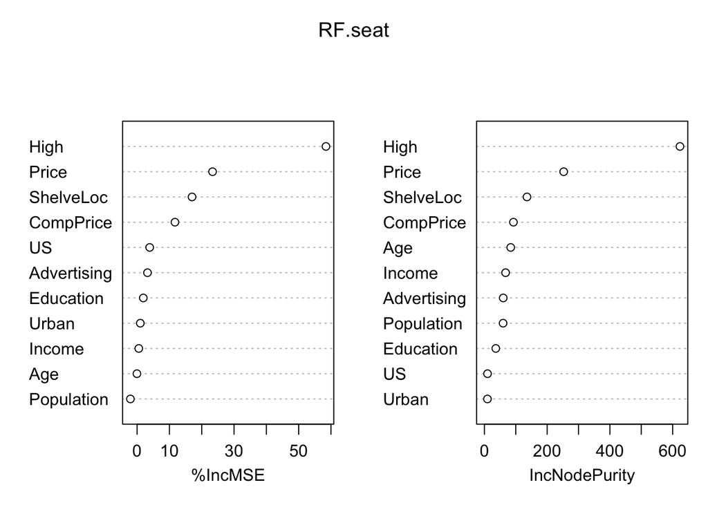

```r
randomForest::varImpPlot(RF.seat)
```

```r
# 10 variables
obb.err=double(10)
test.err=double(10)
for(mtry in 1:10){
  fit=randomForest::randomForest(Sales~.,data=seat_trn,mtry=mtry,ntree=400)
  obb.err[mtry] = fit$mse[400]
  pred=predict(fit,seat_tst)
  test.err[mtry] = with(seat_tst,mean((Sales-pred)^2))
  cat(mtry,"")
}
```

```
## 1 2 3 4 5 6 7 8 9 10
```

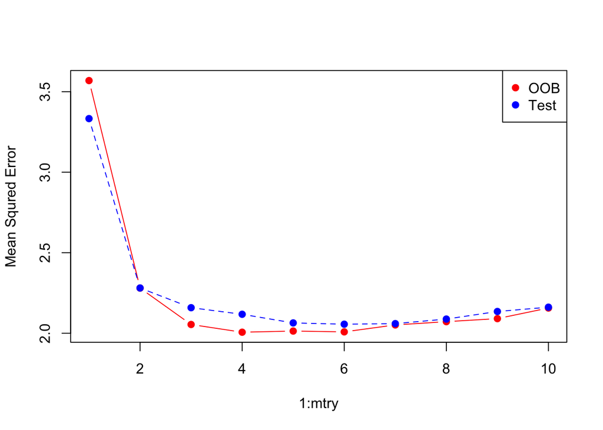

```r
matplot(1:mtry,cbind(test.err,obb.err),pch=19,col=c("red","blue"),type = "b",ylab = "Mean Squred Error")
legend("topright",legend=c("OOB","Test"),pch=19,col = c("red","blue"))
```

```r
(RF.seat = randomForest::randomForest(Sales ~.,data = seat_trn,mtry=6,importance=TRUE))
```

```
##
## Call:
##  randomForest(formula = Sales ~ ., data = seat_trn, mtry = 6,      importance = TRUE)
##                Type of random forest: regression
##                      Number of trees: 500
## No. of variables tried at each split: 6
##
##           Mean of squared residuals: 2.024328
##                     % Var explained: 72.83
```

```r
RF.seat$mse[500]
```

```
## [1] 2.024328
```

test MSE

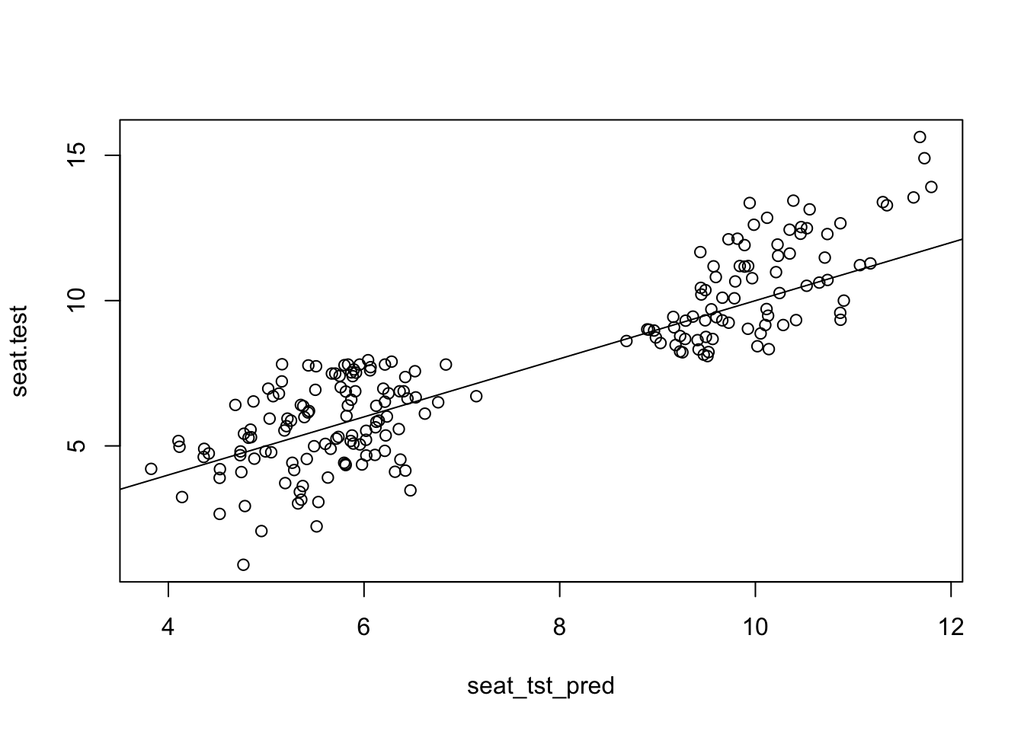

```r
seat_tst_pred = predict(RF.seat,seat_tst)
seat.test = Carseats[-seat_idx,"Sales"]
plot(seat_tst_pred,seat.test)
abline(0,1)
```

```r
mean((seat_tst_pred- seat.test)^2)
```

```
## [1] 1.975888
```

slightly better? than bagging

# Problem 9

```r
data(OJ)
```

```r
dim(OJ)
```

```
## [1] 1070   18
```

```r
?OJ
head(OJ)
```

```
##   Purchase WeekofPurchase StoreID PriceCH PriceMM DiscCH DiscMM SpecialCH
## 1       CH            237       1    1.75    1.99   0.00    0.0         0
## 2       CH            239       1    1.75    1.99   0.00    0.3         0
## 3       CH            245       1    1.86    2.09   0.17    0.0         0
## 4       MM            227       1    1.69    1.69   0.00    0.0         0
## 5       CH            228       7    1.69    1.69   0.00    0.0         0
## 6       CH            230       7    1.69    1.99   0.00    0.0         0
##   SpecialMM  LoyalCH SalePriceMM SalePriceCH PriceDiff Store7 PctDiscMM
## 1         0 0.500000        1.99        1.75      0.24     No  0.000000
## 2         1 0.600000        1.69        1.75     -0.06     No  0.150754
## 3         0 0.680000        2.09        1.69      0.40     No  0.000000
## 4         0 0.400000        1.69        1.69      0.00     No  0.000000
## 5         0 0.956535        1.69        1.69      0.00    Yes  0.000000
## 6         1 0.965228        1.99        1.69      0.30    Yes  0.000000
##   PctDiscCH ListPriceDiff STORE
## 1  0.000000          0.24     1
## 2  0.000000          0.24     1
## 3  0.091398          0.23     1
## 4  0.000000          0.00     1
## 5  0.000000          0.00     0
## 6  0.000000          0.30     0
```

```r
summary(OJ)
```

```
##  Purchase WeekofPurchase     StoreID        PriceCH         PriceMM
##  CH:653   Min.   :227.0   Min.   :1.00   Min.   :1.690   Min.   :1.690
##  MM:417   1st Qu.:240.0   1st Qu.:2.00   1st Qu.:1.790   1st Qu.:1.990
##           Median :257.0   Median :3.00   Median :1.860   Median :2.090
##           Mean   :254.4   Mean   :3.96   Mean   :1.867   Mean   :2.085
##           3rd Qu.:268.0   3rd Qu.:7.00   3rd Qu.:1.990   3rd Qu.:2.180
##           Max.   :278.0   Max.   :7.00   Max.   :2.090   Max.   :2.290
##      DiscCH            DiscMM         SpecialCH        SpecialMM
##  Min.   :0.00000   Min.   :0.0000   Min.   :0.0000   Min.   :0.0000
##  1st Qu.:0.00000   1st Qu.:0.0000   1st Qu.:0.0000   1st Qu.:0.0000
##  Median :0.00000   Median :0.0000   Median :0.0000   Median :0.0000
##  Mean   :0.05186   Mean   :0.1234   Mean   :0.1477   Mean   :0.1617
##  3rd Qu.:0.00000   3rd Qu.:0.2300   3rd Qu.:0.0000   3rd Qu.:0.0000
##  Max.   :0.50000   Max.   :0.8000   Max.   :1.0000   Max.   :1.0000
##     LoyalCH          SalePriceMM     SalePriceCH      PriceDiff       Store7
##  Min.   :0.000011   Min.   :1.190   Min.   :1.390   Min.   :-0.6700   No :714
##  1st Qu.:0.325257   1st Qu.:1.690   1st Qu.:1.750   1st Qu.: 0.0000   Yes:356
##  Median :0.600000   Median :2.090   Median :1.860   Median : 0.2300
##  Mean   :0.565782   Mean   :1.962   Mean   :1.816   Mean   : 0.1465
##  3rd Qu.:0.850873   3rd Qu.:2.130   3rd Qu.:1.890   3rd Qu.: 0.3200
##  Max.   :0.999947   Max.   :2.290   Max.   :2.090   Max.   : 0.6400
##    PctDiscMM        PctDiscCH       ListPriceDiff       STORE
##  Min.   :0.0000   Min.   :0.00000   Min.   :0.000   Min.   :0.000
##  1st Qu.:0.0000   1st Qu.:0.00000   1st Qu.:0.140   1st Qu.:0.000
##  Median :0.0000   Median :0.00000   Median :0.240   Median :2.000
##  Mean   :0.0593   Mean   :0.02731   Mean   :0.218   Mean   :1.631
##  3rd Qu.:0.1127   3rd Qu.:0.00000   3rd Qu.:0.300   3rd Qu.:3.000
##  Max.   :0.4020   Max.   :0.25269   Max.   :0.440   Max.   :4.000
```

```r
#plot(OJ$Purchase,OJ$PriceCH)
```

##9a

```r
# split train vs test
set.seed(2)
train_idx = sample(1:nrow(OJ),800)
OJ_trn = OJ[train_idx,]
OJ_tst = OJ[-train_idx,]
```

##9b

```r
tree.OJ=tree(Purchase~.,data = OJ_trn) # High derived by Sales
summary(tree.OJ)
```

```
##
## Classification tree:
## tree(formula = Purchase ~ ., data = OJ_trn)
## Variables actually used in tree construction:
## [1] "LoyalCH"   "PriceDiff"
## Number of terminal nodes:  9
## Residual mean deviance:  0.7009 = 554.4 / 791
## Misclassification error rate: 0.1588 = 127 / 800
```

Training error rate 0.1588 Terminal node 9

## 9c

```r
tree.OJ
```

```
## node), split, n, deviance, yval, (yprob)
##       * denotes terminal node
##
##  1) root 800 1068.00 CH ( 0.61250 0.38750 )
##    2) LoyalCH < 0.5036 359  422.80 MM ( 0.27577 0.72423 )
##      4) LoyalCH < 0.280875 172  127.60 MM ( 0.12209 0.87791 )
##        8) LoyalCH < 0.035047 56   10.03 MM ( 0.01786 0.98214 ) *
##        9) LoyalCH > 0.035047 116  106.60 MM ( 0.17241 0.82759 ) *
##      5) LoyalCH > 0.280875 187  254.10 MM ( 0.41711 0.58289 )
##       10) PriceDiff < 0.05 73   71.36 MM ( 0.19178 0.80822 ) *
##       11) PriceDiff > 0.05 114  156.30 CH ( 0.56140 0.43860 ) *
##    3) LoyalCH > 0.5036 441  311.80 CH ( 0.88662 0.11338 )
##      6) LoyalCH < 0.737888 168  191.10 CH ( 0.74405 0.25595 )
##       12) PriceDiff < 0.265 93  125.00 CH ( 0.60215 0.39785 )
##         24) PriceDiff < -0.35 12   10.81 MM ( 0.16667 0.83333 ) *
##         25) PriceDiff > -0.35 81  103.10 CH ( 0.66667 0.33333 ) *
##       13) PriceDiff > 0.265 75   41.82 CH ( 0.92000 0.08000 ) *
##      7) LoyalCH > 0.737888 273   65.11 CH ( 0.97436 0.02564 )
##       14) PriceDiff < -0.39 11   12.89 CH ( 0.72727 0.27273 ) *
##       15) PriceDiff > -0.39 262   41.40 CH ( 0.98473 0.01527 ) *
```

This node can be further split into node 8 and 9

##9d

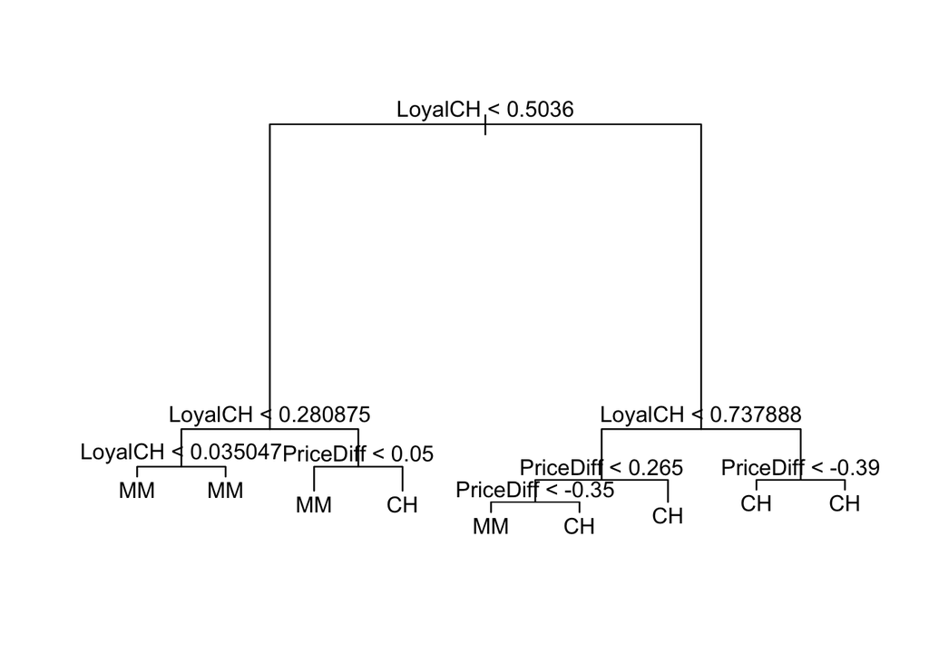

```r
plot(tree.OJ)
text(tree.OJ,pretty = 0)
```

Loyal CH is critical here, while it is then influenced by PriceDiff

##9e test MSE

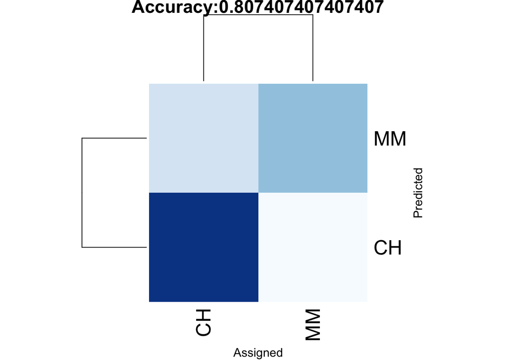

```r
library(RColorBrewer)
OJ_tst_pred = predict(tree.OJ,OJ_tst,type = "class")
confusion1 <- table(predicted=OJ_tst_pred,actual=OJ_tst$Purchase)
treeaccuracy <- paste0("Accuracy:",accuracy(predicted = OJ_tst_pred,actual = OJ_tst$Purchase))

heatmap(confusion1,Rowv = FALSE,Colv = FALSE,symm = TRUE,na.rm = TRUE,xlab = "Assigned",ylab  = "Predicted",main = treeaccuracy, keep.dendro = TRUE,cexRow = 2,cexCol = 2,col= colorRampPalette(brewer.pal(8, "Blues"))(25),margins = c(5,5))
```

##9f&g&h use CV to select a good tree complexity

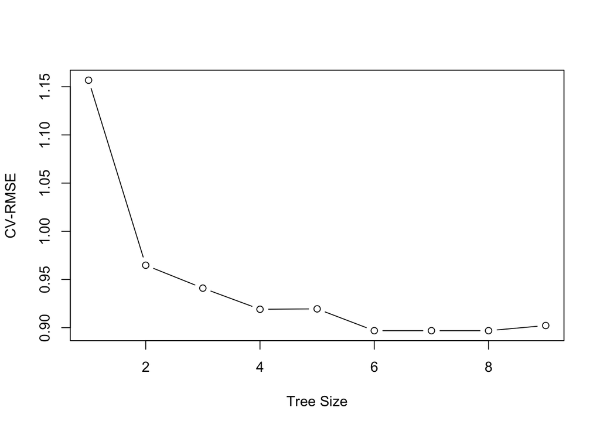

```r
set.seed(18)
OJ_tree_cv = cv.tree(tree.OJ)
plot(OJ_tree_cv$size, sqrt(OJ_tree_cv$dev/nrow(OJ_trn)),type = "b",xlab = "Tree Size",ylab = "CV-RMSE") #?
```

Around 7

##9i&j&k

```r
tree.OJ.prune = prune.tree(tree.OJ,best = 6)
summary(tree.OJ.prune)
```

```
##
## Classification tree:
## snip.tree(tree = tree.OJ, nodes = c(7L, 4L, 12L))
## Variables actually used in tree construction:
## [1] "LoyalCH"   "PriceDiff"
## Number of terminal nodes:  6
## Residual mean deviance:  0.7396 = 587.3 / 794
## Misclassification error rate: 0.1688 = 135 / 800
```

higher…

test error rates

```r
OJ_tst_pred = predict(tree.OJ.prune,OJ_tst,type = "class")
paste0("Accuracy:",accuracy(predicted = OJ_tst_pred,actual = OJ_tst$Purchase))
```

```
## [1] "Accuracy:0.792592592592593"
```

# Problem 10 boosting

```r
data("Hitters")
```

```r
head(Hitters)
```

```
##                   AtBat Hits HmRun Runs RBI Walks Years CAtBat CHits CHmRun
## -Andy Allanson      293   66     1   30  29    14     1    293    66      1
## -Alan Ashby         315   81     7   24  38    39    14   3449   835     69
## -Alvin Davis        479  130    18   66  72    76     3   1624   457     63
## -Andre Dawson       496  141    20   65  78    37    11   5628  1575    225
## -Andres Galarraga   321   87    10   39  42    30     2    396   101     12
## -Alfredo Griffin    594  169     4   74  51    35    11   4408  1133     19
##                   CRuns CRBI CWalks League Division PutOuts Assists Errors
## -Andy Allanson       30   29     14      A        E     446      33     20
## -Alan Ashby         321  414    375      N        W     632      43     10
## -Alvin Davis        224  266    263      A        W     880      82     14
## -Andre Dawson       828  838    354      N        E     200      11      3
## -Andres Galarraga    48   46     33      N        E     805      40      4
## -Alfredo Griffin    501  336    194      A        W     282     421     25
##                   Salary NewLeague
## -Andy Allanson        NA         A
## -Alan Ashby        475.0         N
## -Alvin Davis       480.0         A
## -Andre Dawson      500.0         N
## -Andres Galarraga   91.5         N
## -Alfredo Griffin   750.0         A
```

```r
dim(Hitters)
```

```
## [1] 322  20
```

```r
summary(Hitters)
```

```
##      AtBat            Hits         HmRun            Runs
##  Min.   : 16.0   Min.   :  1   Min.   : 0.00   Min.   :  0.00
##  1st Qu.:255.2   1st Qu.: 64   1st Qu.: 4.00   1st Qu.: 30.25
##  Median :379.5   Median : 96   Median : 8.00   Median : 48.00
##  Mean   :380.9   Mean   :101   Mean   :10.77   Mean   : 50.91
##  3rd Qu.:512.0   3rd Qu.:137   3rd Qu.:16.00   3rd Qu.: 69.00
##  Max.   :687.0   Max.   :238   Max.   :40.00   Max.   :130.00
##
##       RBI             Walks            Years            CAtBat
##  Min.   :  0.00   Min.   :  0.00   Min.   : 1.000   Min.   :   19.0
##  1st Qu.: 28.00   1st Qu.: 22.00   1st Qu.: 4.000   1st Qu.:  816.8
##  Median : 44.00   Median : 35.00   Median : 6.000   Median : 1928.0
##  Mean   : 48.03   Mean   : 38.74   Mean   : 7.444   Mean   : 2648.7
##  3rd Qu.: 64.75   3rd Qu.: 53.00   3rd Qu.:11.000   3rd Qu.: 3924.2
##  Max.   :121.00   Max.   :105.00   Max.   :24.000   Max.   :14053.0
##
##      CHits            CHmRun           CRuns             CRBI
##  Min.   :   4.0   Min.   :  0.00   Min.   :   1.0   Min.   :   0.00
##  1st Qu.: 209.0   1st Qu.: 14.00   1st Qu.: 100.2   1st Qu.:  88.75
##  Median : 508.0   Median : 37.50   Median : 247.0   Median : 220.50
##  Mean   : 717.6   Mean   : 69.49   Mean   : 358.8   Mean   : 330.12
##  3rd Qu.:1059.2   3rd Qu.: 90.00   3rd Qu.: 526.2   3rd Qu.: 426.25
##  Max.   :4256.0   Max.   :548.00   Max.   :2165.0   Max.   :1659.00
##
##      CWalks        League  Division    PutOuts          Assists
##  Min.   :   0.00   A:175   E:157    Min.   :   0.0   Min.   :  0.0
##  1st Qu.:  67.25   N:147   W:165    1st Qu.: 109.2   1st Qu.:  7.0
##  Median : 170.50                    Median : 212.0   Median : 39.5
##  Mean   : 260.24                    Mean   : 288.9   Mean   :106.9
##  3rd Qu.: 339.25                    3rd Qu.: 325.0   3rd Qu.:166.0
##  Max.   :1566.00                    Max.   :1378.0   Max.   :492.0
##
##      Errors          Salary       NewLeague
##  Min.   : 0.00   Min.   :  67.5   A:176
##  1st Qu.: 3.00   1st Qu.: 190.0   N:146
##  Median : 6.00   Median : 425.0
##  Mean   : 8.04   Mean   : 535.9
##  3rd Qu.:11.00   3rd Qu.: 750.0
##  Max.   :32.00   Max.   :2460.0
##                  NA's   :59
```

```r
?Hitters
```

## 10a

```r
Hitter <- na.omit(Hitters,col="Salary")
Hitter$Salary <- log(Hitter$Salary)
```

## 10b

```r
# split train vs test
train_idx = c(1:200)
H_trn = Hitter[train_idx,]
H_tst = Hitter[-train_idx,]
```

##10c & d

```r
library(gbm)
```

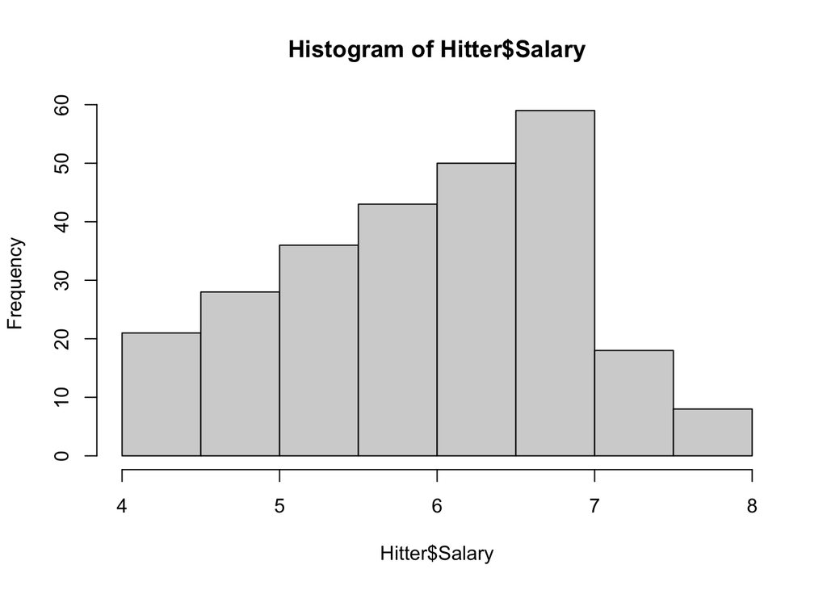

```r
hist(Hitter$Salary)
```

not so gaussian

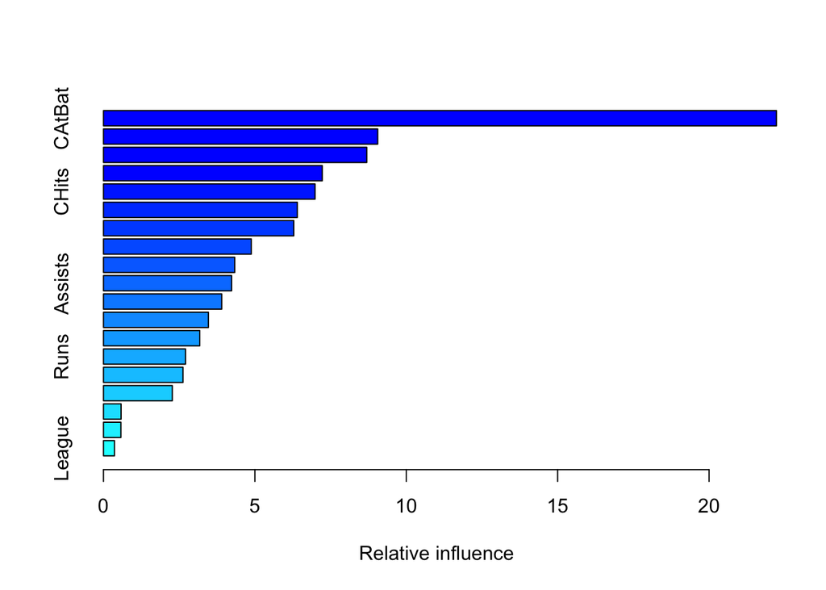

```
##                 var    rel.inf
## CAtBat       CAtBat 22.2258703
## CWalks       CWalks  9.0570120
## CRuns         CRuns  8.6954278
## CRBI           CRBI  7.2259377
## CHits         CHits  6.9874912
## Walks         Walks  6.4007986
## PutOuts     PutOuts  6.2851762
## Years         Years  4.8810085
## AtBat         AtBat  4.3337691
## Assists     Assists  4.2322062
## CHmRun       CHmRun  3.9044650
## RBI             RBI  3.4654285
## Hits           Hits  3.1788352
## Runs           Runs  2.7092129
## HmRun         HmRun  2.6250441
## Errors       Errors  2.2734130
## NewLeague NewLeague  0.5806896
## Division   Division  0.5747819
## League       League  0.3634322
```

```r
boost.H = gbm(Salary ~., data = H_trn,distribution = "gaussian",n.trees = 1e4,shrinkage = 0.01,interaction.depth = 4)

summary(boost.H)
```

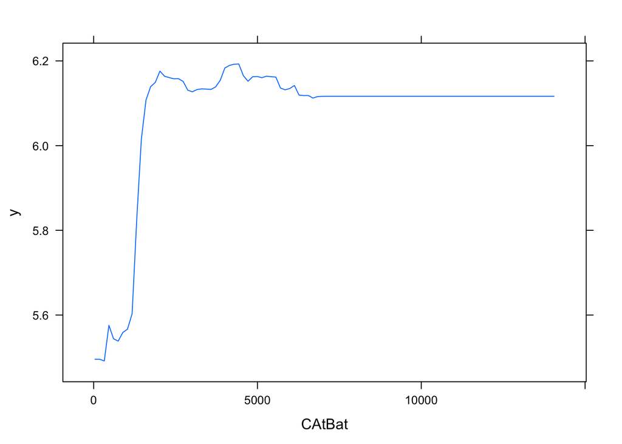

```r
plot(boost.H,i="CAtBat")
```

```r
# lambda_seq=seq(from=0.001,to=0.1,by=0.001)
# predmat = predict(boost.H,newdata = H_tst,shrinkage=lambda_seq)
# dim(predmat)
```

cannot use vectorization?

```r
lambda_seq=seq(from=0.001,to=0.1,by=0.001)
n <- length(lambda_seq)
train_errors <- rep(NA,n)
test_errors <- rep(NA,n)

for (i in 1:length(lambda_seq))
{
  boost.H <- gbm(Salary ~., data = H_trn,distribution = "gaussian",n.trees = 1e3,shrinkage = lambda_seq[i])
  train_pred <- predict(boost.H,H_trn,n.trees = 1e3)
  test_pred <- predict(boost.H,H_tst,n.trees = 1e3)
  train_errors[i]=mean((H_trn$Salary-train_pred)^2)
  test_errors[i]=mean((H_tst$Salary-test_pred)^2)
}
```

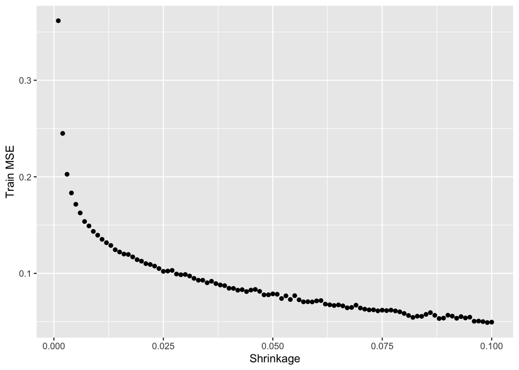

```r
ggplot(data.frame(x=lambda_seq,y=train_errors),aes(x=x,y=y))+xlab("Shrinkage")+ylab("Train MSE") + geom_point()
```

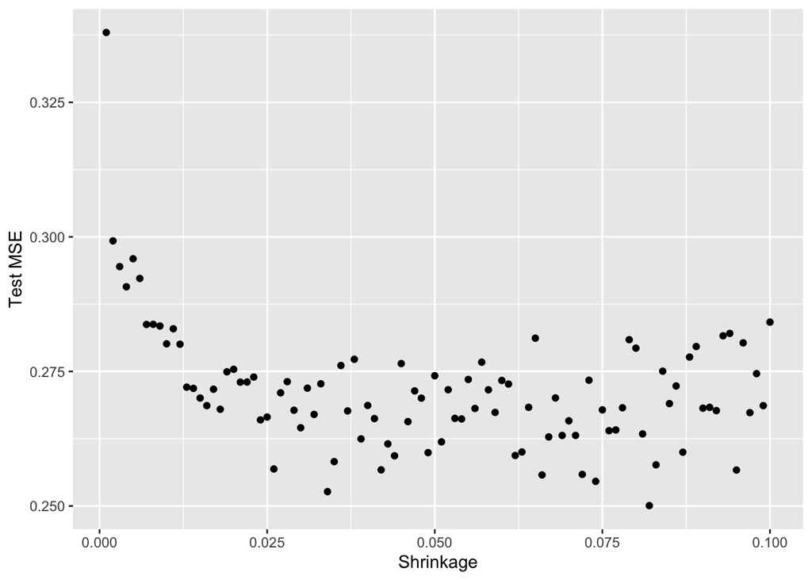

```r
ggplot(data.frame(x=lambda_seq,y=test_errors),aes(x=x,y=y))+xlab("Shrinkage")+ylab("Test MSE") + geom_point()
```

```r
mean(train_errors)
```

```
## [1] 0.08993647
```

```r
mean(test_errors)
```

```
## [1] 0.2713123
```

## 10f

CAtBat

## 10g

```r
(bag.H = randomForest::randomForest(Salary ~.,data = H_trn ,mtry=5,importance=TRUE))
```

```
##
## Call:
##  randomForest(formula = Salary ~ ., data = H_trn, mtry = 5, importance = TRUE)
##                Type of random forest: regression
##                      Number of trees: 500
## No. of variables tried at each split: 5
##
##           Mean of squared residuals: 0.2089774
##                     % Var explained: 74.88
```

```r
bag.H$mse[500]
```

```
## [1] 0.2089774
```

test MSE # do we still need MSE here?

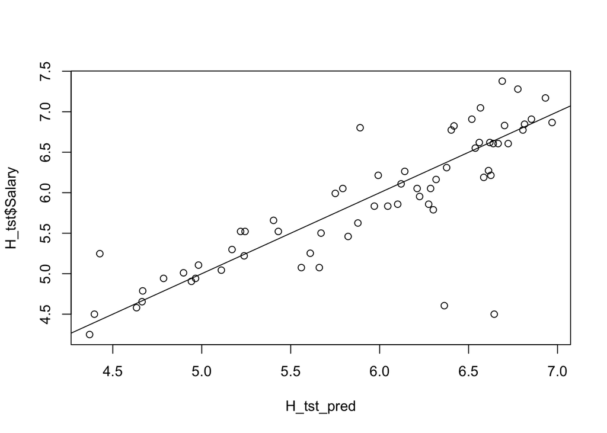

```r
H_tst_pred = predict(bag.H,H_tst)
plot(H_tst_pred,H_tst$Salary)
abline(0,1)
```

```r
mean((H_tst_pred- H_tst$Salary)^2)
```

```
## [1] 0.2123891
```

lower?

# Problem 11